# Načítání eyetrackerových dat do R

Jiří Lukavský

## Přípravy

Nejprve načteme potřebné knihovny: `tidyverse` (moderní knihovna pro práci s daty) a `eyelinker` (pro práci se soubory EyeLinku). Pokud nejsou nainstalované, program je nainstaluje.

```r
if (!require('tidyverse')) install.packages('tidyverse')
if (!require('eyelinker')) install.packages('eyelinker')
library(tidyverse)
library(eyelinker)

# pro poslední ukázku používáme i balíček jpeg
if (!require('jpeg')) install.packages('jpeg')
```

V naší ukázce načteme data z prvního souboru a zobrazíme si je. Dále si definujeme konstanty, které budeme používat při analýze (velikost obrazovky, velikost obrázku).

```r
fn1 <- file.path("..", "data", "r0101.asc")
screen_size = c(1680, 1050)
image_size = c(1024, 1024)
```

## Načtení dat

Pomocí příkazu `read.asc` načteme data. Z výukových důvodů načítáme data takto na začátku souboru s analýzami. U delších dat může import déle trvat a proto jej provádíme obvyklem jen jednou a výsledek zapíše v R formátu (saveRDS).

Výsledkem je seznam tabulek, kde jsou již údaje roztříděné (např. fixace, události a mrknutí zvlášť).

```r
e1 <- eyelinker::read.asc(fn1)

# co obsahuje seznam
names(e1)
```

```
## [1] "raw"    "sacc"   "fix"    "blinks" "msg"    "input"  "button" "info"
```

```r
# zde nás budou zajímat údaje o fixacích a události,
# protože ukazují, kdy začala prezentace obrázku
e1$msg
```

```
## # A tibble: 6 x 3
##   block    time text
##   <dbl>   <dbl> <chr>
## 1     1 4530814 SYNCTIME
## 2     2 4537563 !MODE RECORD CR 2000 2 1 LR
## 3     2 4537702 SYNCTIME
## 4     3 4544120 !MODE RECORD CR 2000 2 1 LR
## 5     3 4544274 SYNCTIME
## 6     4 4551229 SYNCTIME
```

```r
e1$fix
```

```
## # A tibble: 111 x 8
##    block   stime   etime   dur   axp   ayp   aps eye
##    <dbl>   <dbl>   <dbl> <dbl> <dbl> <dbl> <dbl> <fct>
##  1     1 4530665 4531019   354  852.  512.  1793 R
##  2     1 4530665 4531020   355  838.  503.  2137 L
##  3     1 4531045 4531178   133  793.  449.  1619 R
##  4     1 4531046 4531179   133  778.  431.  1963 L
##  5     1 4531192 4531572   380  757   397.  1167 R
##  6     1 4531195 4531574   379  776.  410.  1407 L
##  7     1 4531620 4531735   115 1236.  556.  1271 L
##  8     1 4531628 4531735   107 1188.  535.  1070 R
##  9     1 4531759 4532381   622 1293.  577.  1357 L
## 10     1 4531760 4532382   622 1248.  566.  1173 R
## # ... with 101 more rows
```

Abychom si ušetřili práci, pro případné načitání dat od dalších osob, vytvoříme si krátkou funkci, která nám data připraví pro další analýzu.

```r
fixations_for_each_trial <- function(edata,
           duration = 5000,
           eyes = c("L", "R"),
           origin = c(0, 0),
           imagesize = NULL) {
  # najdeme syncronizační značky mezi událostmi
  sync_messages <-
    edata$msg %>%
    filter(text == "SYNCTIME") %>%
    select(block, time0 = time)
  # k fixacím přidáme data o sychronizační značce (kdy byl zobrazen obrázek)
  # a přepočítáme časy fixací relativně
  fixations <-
    edata$fix %>%
    left_join(sync_messages, by = "block") %>%
    mutate(stime = stime - time0, etime = etime - time0) %>%
    select(-time0)
  # ponecháme jen data pro jedno oko (pokud chceme)
  # přepočítáme souřadnice podle horního levého rohu obrázku
  fixations <-
    fixations %>%
    filter(eye %in% eyes) %>%
    mutate(x = axp - origin[1], y = ayp - origin[2], inside = NA_integer_)
  # pro jednotlivé fixace si označíme, zda dopadaly na obrázek nebo
  # za jeho hranice (usnadní nám jejich případné zahození)
  if (!is.null(imagesize)) {
    fixations <- fixations %>%
      mutate(inside =
               (x >= 0) & (x <= imagesize[1]) &
               (y >= 0) & (y <= imagesize[2]))
  }
  # odstraníme fixace před začátkem nebo po konci trialu
  fixations <-
    fixations %>%
    filter(etime > 0, stime < duration)
  # vrátíme jednu tabulku s fixacemi
  fixations %>%
    select(block, stime, etime, eye, x, y, dur, pupil = aps, inside)
}
```

Nyní si načteme data a podíváme se na ně.

```r
ff1 <- fixations_for_each_trial(
  e1,
  origin = screen_size / 2 - image_size / 2,
  imagesize = image_size
)
ff1
```

```
## # A tibble: 111 x 9
##    block stime etime eye       x     y   dur pupil inside
##    <dbl> <dbl> <dbl> <fct> <dbl> <dbl> <dbl> <dbl> <lgl>
##  1     1  -149   205 R      524.  499.   354  1793 TRUE
##  2     1  -149   206 L      510.  490.   355  2137 TRUE
##  3     1   231   364 R      465.  436.   133  1619 TRUE
##  4     1   232   365 L      450.  418.   133  1963 TRUE
##  5     1   378   758 R      429   384.   380  1167 TRUE
##  6     1   381   760 L      448.  397.   379  1407 TRUE
##  7     1   806   921 L      908.  543.   115  1271 TRUE
##  8     1   814   921 R      860.  522.   107  1070 TRUE
##  9     1   945  1567 L      965.  564.   622  1357 TRUE
## 10     1   946  1568 R      920.  553.   622  1173 TRUE
## # ... with 101 more rows
```

## Zobrazení dat

Nyní již máme data v tabulce pro další zpracování a mohla by následovat statistická analýza.

Můžeme si data také zobrazit. Obrázek ukazuje fixace jednoho člověka při prohlížení všech čtyř obrázků. Jednotlivé fixace můžete vidět dvakrát, protože jsme ponechali data z obou očí.

Při tvorbě obrázků otáčíme souřadnice osy y (-y), protože pixelové souřadnice mají počátek vlevo nahoře a směrem dolů rostou, ale v grafech je počátek vlevo dole a směrem nahoru roste.

Příkaz `coor_fixed` používáme, aby byla zachována pixelová vzdálenost na osách x a y.

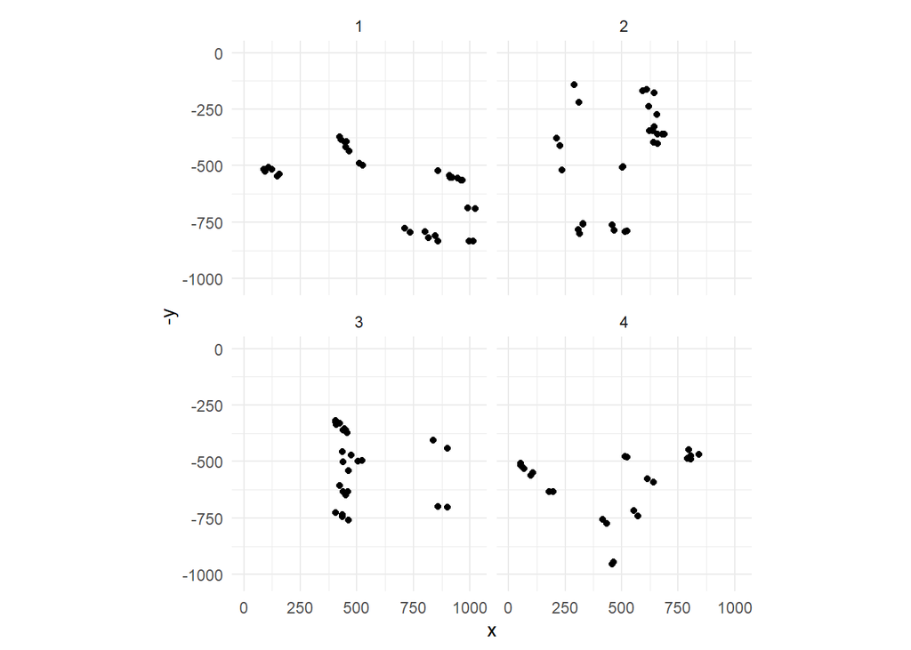

```r
ggplot(ff1, aes(x, -y)) +
  geom_point() +
  theme_minimal() +
  coord_fixed(xlim = c(0, image_size[1]),
              ylim = c(-image_size[2], 0)) +
  facet_wrap(~block)
```

Do grafu je možné přidat i sakády a velikost bodů upravit podle délky fixací, podobně jako v Data Vieweru.

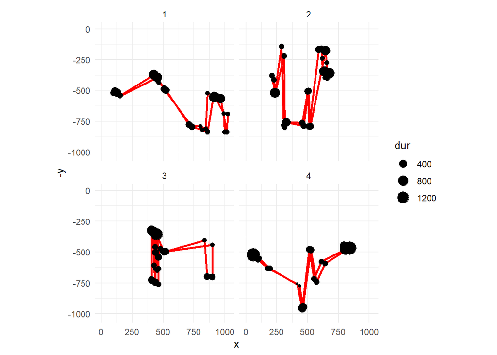

```r
ggplot(ff1, aes(x, -y, group = eye, size = dur)) +
  geom_line(col = "red", size = 1) +
  geom_point() +
  theme_minimal() +
  coord_fixed(xlim = c(0, image_size[1]),
              ylim = c(-image_size[2], 0)) +
  facet_wrap(~block)
```

Do grafu je možné přidat i původní obrázek.

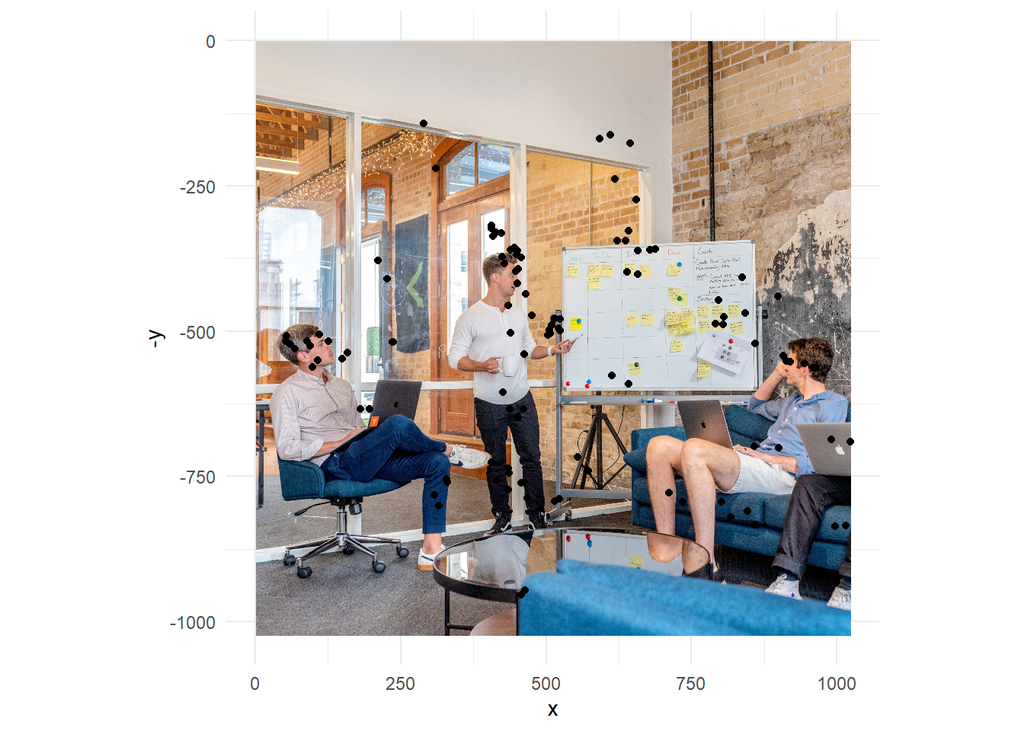

```r
im1 <- jpeg::readJPEG(file.path("..", "images", "image_001.jpg"))

ggplot(ff1, aes(x, -y)) +
  annotation_custom(grid::rasterGrob(im1),
                    0, 1024, -1024, 0) +
  geom_point() +
  theme_minimal() +
  coord_fixed(xlim = c(0, image_size[1]),
              ylim = c(-image_size[2], 0))
```